# Notebook 1: get_traffic_weather_data

```python
import requests
from datetime import datetime, timedelta
import csv
weather_key = ""  # OpenWeatherMap API Key
traffic_key = ""  # TomTom API Key

start_latitude = "31.789181080129165"
start_longitude = "35.20615277800434"

end_latitude = "32.058876700901706"
end_longitude = "34.759167362895944"

weather_base_url = "https://history.openweathermap.org/data/2.5/history"
traffic_base_url = "https://api.tomtom.com/routing/1/calculateRoute/"

start_date = datetime(2022, 6, 14)
end_date = datetime(2023, 6, 14)
```

`get_tomtom_traffic_data(api_key, start_time)`

**Functionality:** This function retrieves traffic data using the TomTom Traffic API. The function converts the start_time to a specific string, which is required by the TomTom API It then checks whether the request was successful or not.

**Input:**

- **api_key:** The API key for accessing the TomTom Traffic API.
- **start_time:** The starting time for which traffic data is requested.

**Output:**

- **departure_time:** The departure time of the route.
- **arrival_time:** The arrival time of the route.
- **distance:** The distance of the route in kilometers.
- **travel_time:** The travel time of the route in minutes.

```python
def get_tomtom_traffic_data(api_key, start_time):
    start_time_str = start_time.strftime("%Y-%m-%dT%H:%M:%S")
    traffic_url = f"{traffic_base_url}/{start_latitude}%2C{start_longitude}%3A{end_latitude}%2C{end_longitude}/json?departAt={start_time_str}&key={api_key}"
    response = requests.get(traffic_url)
    if response.status_code == 200:
        json_result = response.json()
        route_summary = json_result['routes'][0]['summary']
        distance = round(route_summary['lengthInMeters'] / 1000, 2)
        travel_time = int(route_summary['travelTimeInSeconds'] / 60)
        departure_time = route_summary['departureTime']
        arrival_time = route_summary['arrivalTime']
        return departure_time, arrival_time, distance, travel_time
    else:
        print(f"Request to TomTom Traffic API failed with status code {response.status_code}")
        return None
```

`get_openweathermap_data(api_key, date)`

**Functionality:** The function converts the date to UNIX time format (seconds since Jan 1. 1970 'till given date) , which is required by the OpenWeatherMap API. Since the API returns data for each hour of the same day (unlike TomTom), it's much simpler

**Input:**

- **api_key:** The API key for accessing the OpenWeatherMap API.
- **date:** The date for which weather data is requested.

**Output:**

- **weather_data:** A list of dictionaries containing weather information for each hour of the specified date.

```python
def get_openweathermap_data(api_key, date):
    date_unix = int(date.timestamp())
    weather_url = f"{weather_base_url}/city?lat={start_latitude}&lon={start_longitude}&type=hour&start={date_unix}&units=metric&appid={api_key}"
    response = requests.get(weather_url)
    if response.status_code == 200:
        weather_info = response.json()
        weather_data = []
        for hour_data in weather_info["list"]:
            date_time = datetime.fromtimestamp(hour_data["dt"])
            temperature = hour_data["main"]["temp"]
            weather_conditions = hour_data["weather"]
            weather_main = weather_conditions[0]["main"]

            weather_entry = {
                "Date": date_time.strftime("%Y-%m-%d"),
                "Time": date_time.strftime("%H:%M"),
                "Temperature": temperature,
                "Weather": weather_main
            }

            weather_data.append(weather_entry)

        return weather_data
    else:
        print(f"Failed to retrieve weather data for {date}")
        return []
```

`write_data_to_csv(file_path, data)`

**Functionality:** This function writes all the data returned from the fuctions above to a CSV

**Input:**

- **file_path:** The file path of the CSV file to be created.
- **data:** The collected data to be written to the CSV file.

**Output:** None

```python
def write_data_to_csv(file_path, data):
    with open(file_path, "w", newline="") as file:
        writer = csv.writer(file)
        writer.writerow([
            "Date",
            "Hour",
            "Length (Kilometers)",
            "Travel Time (Minutes)",
            "Speed (km/h)",
            "Arrival Time",
            "Temperature",
            "Weather"
        ])

        for entry in data:
            writer.writerow([
                entry["Date"],
                entry["Time"],
                entry["Length"],
                entry["Travel Time"],
                entry["Speed"],
                entry["Arrival Time"],
                entry["Temperature"],
                entry["Weather"]
            ])
```

`collect_data(start_date, end_date)`

**Functionality:** This function collects data in a loop, starting with *start_date* and ends with *end_date*. the data goes into a 'data' list, which then includes both TomTom and OpenWeatherMap datasets The function basically goes through each day - goes to `get_openweathermap_data` with the *current_date*, and then breaks the day into 24 hours For each hour, `get_tomtom_traffic_data` gets called on the specific day and time All the data is then appended to the specified column, which is later converted into a CSV file.

**Input:**

- **start_date:** The starting date of the data collection.
- **end_date:** The ending date of the data collection.

**Output:**

- **data:** A list of dictionaries containing the collected data

```python
def collect_data(start_date, end_date):
    data = []

    current_date = start_date
    while current_date <= end_date:
        weather_data = get_openweathermap_data(weather_key, current_date)

        for hour in range(24):
            start_time = current_date.replace(hour=hour, minute=0, second=0)
            traffic_data = get_tomtom_traffic_data(traffic_key, start_time)
            hour_time = start_time.strftime("%H:%M")

            if traffic_data is not None:
                departure_time, arrival_time, length, travel_time = traffic_data

                length = round(length, 2)
                travel_time = int(travel_time)
                speed = int((length / (travel_time / 60)))

                weather_entry = next((entry for entry in weather_data if entry["Time"] == hour_time), None)
                if weather_entry:
                    data.append({
                        "Date": current_date.strftime("%Y-%m-%d"),
                        "Time": hour_time,
                        "Length": length,
                        "Travel Time": travel_time,
                        "Speed": speed,
                        "Arrival Time": arrival_time,
                        "Temperature": weather_entry["Temperature"],
                        "Weather": weather_entry["Weather"]
                    })
                else:
                    data.append({
                        "Date": current_date.strftime("%Y-%m-%d"),
                        "Time": hour_time,
                        "Length": "",
                        "Travel Time": "",
                        "Speed": "",
                        "Arrival Time": "",
                        "Temperature": "",
                        "Weather": ""
                    })

        current_date += timedelta(days=1)

    return data
```

`main`

This is the main function that orchestrates the data collection and CSV file writing process.

```python
#This part costs $$$. Do not run unless required

if __name__ == "__main__":
    file_path = "data.csv"

    collected_data = collect_data(start_date, end_date)
    write_data_to_csv(file_path, collected_data)

    print("Done")
```

```
Done
```

# Notebook 2: EDA

```python
import pandas as pd
import datetime
import matplotlib.pyplot as plt

# Load the data from the CSV file
data = pd.read_csv("data.csv")
```

`statistics(data)`

**Functionality:** Display the first few rows of the data and generate descriptive statistics of the numerical columns.

**Parameters:**

- **data (DataFrame):** Input data loaded from the CSV file.

**Output:** None

```python
def statistics(data):
    # Display the first few rows of te data
    print(data.head())


    # Generate descriptive statistics of the numerical columns
    print(data.describe())
```

`missingData(data)`

**Functionality:** Check for missing values in each column and fill missing values with appropriate strategies.

**Parameters:**

- **data (DataFrame):** Input data loaded from the CSV file.

**Output:** None

```python
def missingData(data):
    # Check for missing values in each column
    print(data.isnull().sum())

    # Fill  missing values with approproate strategies
    # For example, fill missing numerical values with mean
    data["Length (Kilometers)"].fillna(data["Length (Kilometers)"].mean(), inplace=True)
    data["Travel Time (Minutes)"].fillna(data["Travel Time (Minutes)"].mean(), inplace=True)

    # For categorial variables, fill missing values with mode
    data["Weather"].fillna(data["Weather"].mode()[0], inplace=True)
```

`commonDistance(data)`

**Functionality:** Plot a histogram of the "Length" variable.

**Parameters:**

- **data (DataFrame):** Input data loaded from the CSV file.

**Output:** None

```python
def commonDistance(data):
    # Plot a histogram of the "Length" variable
    plt.hist(data["Length (Kilometers)"], bins=10)
    plt.xlabel("Length (Kilometers)")
    plt.ylabel("Frequency")
    plt.title("Distribution of Length")
    plt.show()
```

`travelTimePlotBox(data)`

**Functionality:** Create a box plot of the "Travel Time" variable.

**Parameters:**

- **data (DataFrame):** Input data loaded from the CSV file.

**Output:** None

```python
def travelTimePlotBox(data):
    # Create a box plot of the "Travel Time" variable
    plt.boxplot(data["Travel Time (Minutes)"])
    plt.ylabel("Travel Time (Minutes)")
    plt.title("Distribution of Travel Time")
    plt.show()
```

`commonWeatherBarPlt(data)`

**Functionality:** Create a bar plot for the "Weather" variable.

**Parameters:**

- **data (DataFrame):** Input data loaded from the CSV file.

**Output:** None

```python
def commonWeatherBarPlt(data):
    # Create a bar plot for the "Weather" variable
    weather_counts = data["Weather"].value_counts()
    plt.bar(weather_counts.index, weather_counts.values)
    plt.xlabel("Weather")
    plt.ylabel("Count")
    plt.title("Frequency of Weather Conditions")
    plt.show()
```

`correlationMatrix(data)`

**Functionality:** Calculate the correlation matrix and create a heatmap.

**Parameters:**

- **data (DataFrame):** Input data loaded from the CSV file.

**Output:** None

```python
def correlationMatrix(data):

    # Calculate the correlation matrix
    correlation_matrix = data[["Length (Kilometers)", "Travel Time (Minutes)", "Speed (km/h)", "Temperature"]].corr()

    # Create a heatmap of the correlation matrix
    plt.imshow(correlation_matrix, cmap="coolwarm", interpolation="nearest")
    plt.colorbar()
    plt.xticks(range(len(correlation_matrix.columns)), correlation_matrix.columns, rotation=45)
    plt.yticks(range(len(correlation_matrix.columns)), correlation_matrix.columns)
    plt.title("Correlation Matrix")
    plt.show()
```

`averageTravelTimeInWeek(data)`

**Functionality:** Calculate the average travel time for each day of the week and plot the results.

**Parameters:**

- **data (DataFrame):** Input data loaded from the CSV file.

**Output:** None

```python
def averageTravelTimeInWeek(data):
    # Convert the "Date" column to datetime format
    data["Date"] = pd.to_datetime(data["Date"])

    # Extract the day of the week from the "Date" column
    data["DayOfWeek"] = data["Date"].dt.day_name()

    # Define the order of the weekdays
    weekdays_order = ["Sunday", "Monday", "Tuesday", "Wednesday", "Thursday", "Friday", "Saturday"]

    # Calculate the average travel time for each day of the week
    average_travel_time = data.groupby("DayOfWeek")["Travel Time (Minutes)"].mean().reindex(weekdays_order)

    # Plot the linear graph
    plt.plot(average_travel_time.index, average_travel_time.values)
    plt.xlabel("Day of the Week")
    plt.ylabel("Average Travel Time (Minutes)")
    plt.title("Average Travel Time by Day of the Week")
    plt.xticks(rotation=45)
    plt.show()
```

`averageTravelTimeByMonth(data)`

**Functionality:** Calculate the average travel time for each month and year and plot the results.

**Parameters:**

- **data (DataFrame):** Input data loaded from the CSV file.

**Output:** None

```python
def averageTravelTimeByMonth(data):
    # Extract the month and year from the "Date" column
    data["Month"] = data["Date"].dt.month
    data["Year"] = data["Date"].dt.year

    # Calculate the average travel time for each month and year
    average_travel_time = data.groupby(["Year", "Month"])["Travel Time (Minutes)"].mean().reset_index()

    # Sort the data by month and year
    average_travel_time.sort_values(["Year", "Month"], inplace=True)

    # Convert the month number to month name
    month_names = pd.date_range(start="2023-01-01", periods=12, freq="MS").strftime("%B").tolist()
    average_travel_time["Month"] = average_travel_time["Month"].map(lambda x: month_names[x-1])

    # Remove the duplicate data point for the first month
    average_travel_time = average_travel_time.iloc[1:]

    # Plot the linear graph
    plt.plot(average_travel_time["Month"], average_travel_time["Travel Time (Minutes)"], marker="o")
    plt.xlabel("Month")
    plt.ylabel("Average Travel Time (Minutes)")
    plt.title("Average Travel Time by Month")
    plt.xticks(rotation=45)
    plt.show()
```

`averageTravelTimeByHour(data)`

**Functionality:** Calculate the average travel time for each hour of the day and plot the results.

**Parameters:**

- **data (DataFrame):** Input data loaded from the CSV file.

**Output:** None

```python
def averageTravelTimeByHour(data):

    # Read the data from the CSV file
    data = pd.read_csv('data.csv')

    # Calculate the average travel time for each hour
    average_travel_time = data.groupby(data['Hour'].astype(str).str[:2])['Travel Time (Minutes)'].mean().reset_index()

    # Plot the graph
    plt.plot(average_travel_time['Hour'], average_travel_time['Travel Time (Minutes)'])
    plt.xlabel('Hour of the Day')
    plt.ylabel('Average Travel Time (Minutes)')
    plt.title('Average Travel Time by Hour of the Day')
    plt.xticks(range(24))
    plt.grid(True)
    plt.show()
```

`averageTravelTimeByWeather(data)`

**Functionality:** Calculate the average travel time for each weather category and plot the results.

**Parameters:**

- **data (DataFrame):** Input data loaded from the CSV file.

**Output:** None

```python
def averageTravelTimeByWeather(data):
    # Read the data from the CSV file
    data = pd.read_csv('data.csv')

    # Define the desired order of weather categories
    weather_order = ['Clear', 'Rain', 'Clouds']

    # Calculate the average travel time for each weather category
    average_travel_time = data.groupby('Weather')['Travel Time (Minutes)'].mean().reset_index()

    # Convert average travel time to "MM:SS" format
    average_travel_time['Travel Time (Minutes)'] = average_travel_time['Travel Time (Minutes)'].apply(lambda x: str(datetime.timedelta(seconds=int(x*60)))[-5:])

    # Reorder the rows based on the defined weather order
    average_travel_time['Weather'] = pd.Categorical(average_travel_time['Weather'], categories=weather_order, ordered=True)
    average_travel_time.sort_values('Weather', inplace=True)

    # Create a scatter plot with average travel time
    plt.scatter(average_travel_time['Weather'], average_travel_time['Travel Time (Minutes)'], color='blue', marker='o', label='Average Travel Time')
    plt.plot(average_travel_time['Weather'], average_travel_time['Travel Time (Minutes)'], color='red', linestyle='-', linewidth=2)
    plt.xlabel('Weather')
    plt.ylabel('Average Travel Time (MM:SS)')
    plt.title('Average Travel Time by Weather')
    plt.legend()
    plt.grid(True)
    plt.show()
```

# Call the functions

```
         Date   Hour  Length (Kilometers)  Travel Time (Minutes)  \
0  2022-06-14  00:00                62.21                   48.0
1  2022-06-14  01:00                62.21                   48.0
2  2022-06-14  02:00                62.21                   48.0
3  2022-06-14  03:00                62.21                   48.0
4  2022-06-14  04:00                62.21                   49.0

   Speed (km/h)               Arrival Time  Temperature Weather
0          77.0  2022-06-14T00:48:39+03:00        17.47   Clear
1          77.0  2022-06-14T01:48:39+03:00        17.46   Clear
2          77.0  2022-06-14T02:48:39+03:00        17.43   Clear
3          77.0  2022-06-14T03:48:39+03:00        16.88  Clouds
4          76.0  2022-06-14T04:49:16+03:00        16.43  Clouds
       Length (Kilometers)  Travel Time (Minutes)  Speed (km/h)  Temperature
count          8736.000000            8736.000000   8734.000000  8734.000000
mean             63.040256              53.888253     70.390886    17.924322
std               0.955272               5.910174      6.411386     6.512455
min              62.210000              48.000000     56.000000     3.030000
25%              62.210000              48.000000     65.000000    12.550000
50%              62.210000              52.000000     71.000000    18.065000
75%              64.120000              59.000000     77.000000    22.530000
max              64.590000              68.000000     77.000000    37.280000
Date                     0
Hour                     0
Length (Kilometers)      0
Travel Time (Minutes)    0
Speed (km/h)             2
Arrival Time             2
Temperature              2
Weather                  0
dtype: int64
```

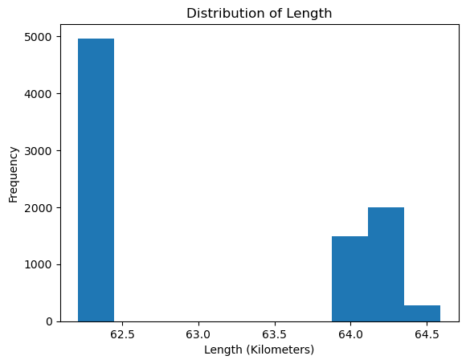

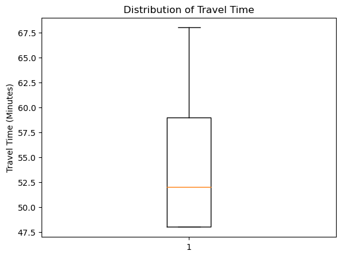

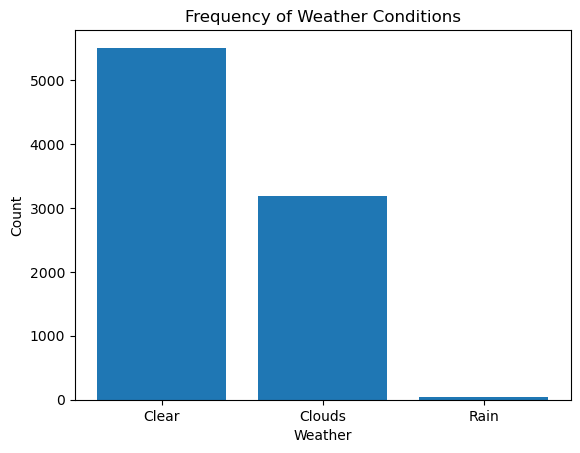

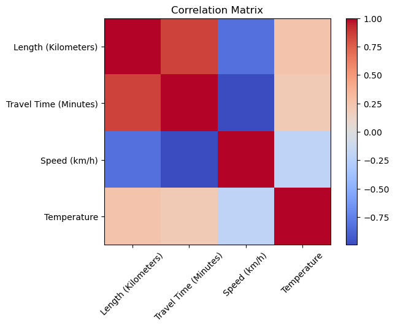

```python
statistics(data)
missingData(data)
commonDistance(data)
travelTimePlotBox(data)
commonWeatherBarPlt(data)
correlationMatrix(data)
averageTravelTimeInWeek(data)
averageTravelTimeByMonth(data)
averageTravelTimeByWeather(data)
```

[output not shown]

# Notebook 3: Machine Learning

```python
import pandas as pd
from datetime import datetime
import matplotlib.pyplot as plt
import requests
import re

data = pd.read_csv("data.csv")
```

`DayDifference(start_date, end_date)`

**Functionality:** Calculates the number of days between two dates.

**Input:**

- **start_date:** Start date in the format "*YYYY-MM-DD*".
- **end_date:** End date in the format "*YYYY-MM-DD*".

**Output:** The number of days between *start_date* and *end_date*.

```python
def DayDifference(start_date, end_date):
    start_datetime = datetime.strptime(start_date, "%Y-%m-%d")
    end_datetime = datetime.strptime(end_date, "%Y-%m-%d")

    day_difference = (end_datetime - start_datetime).days

    return day_difference
```

`GetDayName(date_string)`

**Functionality:** Extracts the day name (e.g., *Monday, Tuesday*) from a given date.

**Input:**

- **date_string:** Date in the format "*YYYY-MM-DD*".

**Output:** The day name corresponding to the given date_string.

```python
def GetDayName(date_string):
    # Assuming date_string is in the format "YYYY-MM-DD"
    dt = datetime.strptime(date_string, "%Y-%m-%d")

    # Get the day name
    day_name = dt.strftime("%A")

    return day_name
```

`TimeDiffrence(time1, time2)`

**Functionality:** Calculates the time difference in hours between two times.

**Input:**

- **time1:** Start time in the format "HH:MM".
- **time2:** End time in the format "HH:MM".

**Output:** The time difference in hours between time1 and time2.

```python
def TimeDiffrence(time1, time2):
    time1 = datetime.strptime(time1, "%H:%M")
    time2 = datetime.strptime(time2, "%H:%M")
    #Calculate the time difference in hours
    difference = (time2 - time1).total_seconds() / 3600

    return round(difference, 2)
```

`GetDayNumber(dayName)`

**Functionality:** Retrieves the numeric representation of a day of the week (*0 for Sunday, 1 for Monday, etc.*).

**Input:**

- **dayName:** Name of the day (e.g., *Sunday, Monday*).

**Output:** The numeric representation of the given *dayName*.

```python
def GetDayNumber(dayName):
    days = { 'Sunday': 0, 'Monday': 1,  'Tuesday': 2,   'Wednesday': 3,   'Thursday': 4,
            'Friday': 5,  'Saturday': 6}

    return days.get(dayName, None)
```

`GetHourNumber(time_str)`

**Functionality:** Extracts the hour component from a given time.

**Input:**

- **time_str:** Time in the format "*HH:MM*".

**Output:** The hour component of the given *time_str*.

```python
def GetHourNumber(time_str):
    try:
        # Parse the time string
        time = datetime.strptime(time_str, "%H:%M").time()

        # Get the hour component
        hour_number = time.hour

        return hour_number
    except ValueError:
        return None
```

`GetWeatherNumber(weather)`

**Functionality:** Retrieves the numeric representation of a weather state (0 for *Clear*, 1 for *Clouds*, 2 for *Rain*).

**Input:**

- **weather:** Weather state (e.g., *Clear, Clouds, Rain*).

**Output:** The numeric representation of the given weather.

```python
def GetWeatherNumber(weather):
    weathers = {'Clear' : 0, 'Clouds' : 1, 'Rain' : 2}

    return weathers.get(weather, None)
```

`CalculateTime(dataFrameRow)`

**Functionality:** Calculates the adjusted travel time based on various factors (*day, hour, weather*).

**Input:**

- **dataFrameRow:** A row from a DataFrame containing travel data.

**Output:** The adjusted travel time.

```python
def CalculateTime(dataFrameRow):
    # Modifer base on busy days starting from Sunday until Saturday
    dayArrayModifer = [0.07, 0.1, 0.1, 0.09, 0.11, -0.14, - 0.23]

    # Modifer base on busy hours starting from 00:00 until 23:00
    timeArrayModifer = [-0.17, -0.17, -0.19, -0.16, -0.14, -0.11, -0.05, 0.2, 0.2, 0.11, 0.08, 0.1,
                        0.11, 0.12, 0.13, 0.16, 0.23, 0.25, 0.13, 0.05, -0.05, -0.15, -0.21, -0.21]

    # Modifer base on weather state [Clear, Clouds, Rain]
    weatherArrayModifer = [-0.05, -0.05, 0.1]

    length = float(dataFrameRow[2])
    averageSpeed = float(dataFrameRow[4])
    dayNumber = GetDayNumber(GetDayName(dataFrameRow[0]))
    hourNumber = GetHourNumber(dataFrameRow[1])
    weatherNumber = GetWeatherNumber(dataFrameRow[7])

    newTravelTime = length / averageSpeed * 60

   #print ("newTravelTime", newTravelTime)
   #print ("dayNumber", dayNumber)
   #print ("hourNumber", hourNumber)
   #print ("weatherNumber", weatherNumber)

    if (dayNumber != None):
        dayModifer = newTravelTime * dayArrayModifer[dayNumber] * 0.3
    else:
        dayModifer = 0

    if (hourNumber != None):
        hourModifer = newTravelTime * timeArrayModifer[hourNumber] * 0.6
    else:
        hourModifer = 0

    if (weatherNumber != None):
        weatherModifer = newTravelTime * weatherArrayModifer[weatherNumber] * 0.1
    else:
        weatherModifer = 0;

    newTravelTime += dayModifer + hourModifer + weatherModifer

    return newTravelTime
```

`PerformanceAppraisal()`

**Functionality:** Calculates the overall accuracy of the algorithm based on n all the data we've collected. We have tested it on the dates that we've already know what's the travel time of and run it through our algorithm. Based on that, we've achieved pretty close results. If there are some missing parameters in a row of a data frame we ignore it for the calculation.

**Input:** None.

**Output:** Prints the overall measured average *travel time*, *calculated average travel time*, and the *accuracy percentage*.

```python
def PerformanceAppraisal():

    counter = 0
    row_number = data.index
    measuredTravelTime = 0
    calculateTravelTime = 0
    deltaTraveltime = 0

    for index in row_number:
        tempTravelTime = CalculateTime(data.loc[index])
        if tempTravelTime != None and tempTravelTime > 0:
            measuredTravelTime += data.loc[index][3]
            calculateTravelTime += tempTravelTime
            counter += 1

    if counter == 0:
        print ("Counter equel to zero ERROR")
    else:
        measuredTravelTime = measuredTravelTime / counter
        calculateTravelTime = calculateTravelTime / counter
        deltaTraveltime = measuredTravelTime - calculateTravelTime
        deltaTraveltime = abs(deltaTraveltime)
        deltaPercantage = round(100 - (measuredTravelTime * deltaTraveltime / 100),2)
        print (f"\n\nOverall measured average travel time is {measuredTravelTime}")
        print (f"Overall calculate average travel time is {calculateTravelTime}")
        print (f"The accuracy percantage is {deltaPercantage}%")
```

`Predict(date, time)`

**Functionality:** Estimates the travel time based on the given date and time.

**Input:**

- **date:** Date in the format "*YYYY-MM-DD*".
- **time:** Time in the format "*HH:MM*".

**Output:** Prints the estimated travel time.

```python
def Predict(date, time):

    pattern = r"\b\d{4}-\d{2}-\d{2}\b"
    match = re.search(pattern, date)
    if match is None:
        return print ("ERROR! illegal date input!")

    pattern = r"\b\d{2}:\d{2}\b"
    match = re.search(pattern, time)
    if match is None:
        return print ("ERROR! illegal time input!")

    currDate = datetime.now().date().strftime("%Y-%m-%d")

    # Check if the selected date has already passed
    if DayDifference(currDate, date) < 0:
        start_time_str = date + "T" + time + ":00"
        traffic_url = f"https://api.tomtom.com/routing/1/calculateRoute/31.789181080129165%2C35.20615277800434%3A32.058876700901706%2C34.759167362895944/json?departAt={start_time_str}&key="
        response = requests.get(traffic_url)
        if response.status_code == 200:
            json_result = response.json()
            route_summary = json_result['routes'][0]['summary']
            travel_time = int(route_summary['travelTimeInSeconds'] / 60)
            print(f"The travel time was {travel_time} minutes")
        else:
            print(f"Request to TomTom Traffic API failed with status code {response.status_code}")
            print(traffic_url)
  #return print("Selected date has already passed")

    # Get the selected day name
    selectedDay = GetDayName(date)

    counter = 0
    avarageTravelTime = 0

    row_number = data.index

    for index in row_number:
        if GetDayName(data.loc[index][0]) == selectedDay:
            if abs(TimeDiffrence(time, data.loc[index][1])) <= 1:
                tempTravelTime = CalculateTime(data.loc[index])
                if tempTravelTime != None and tempTravelTime > 0:
                    avarageTravelTime += tempTravelTime
                    counter += 1

    if counter != 0 and avarageTravelTime > 0:
        print ("Estimated travel time is", int(avarageTravelTime / counter), "minutes")
    else:
        print ("Couldn't calculate travel time")
```

```python
Predict("2023-06-19", "09:29")
PerformanceAppraisal()
```

```
The travel time was 59 minutes
Estimated travel time is 64 minutes


Overall measured average travel time is 53.888252805129376
Overall calculate average travel time is 55.13545499055923
The accuracy percantage is 99.33%
```